# P&S-2025 Lab assignment 2

Hamaniuk, Antoniuk, Maharyta

## General comments and instructions

Distribution:

- Iia Maharyta: task 1 and conclusions;
- Maria Hamaniuk: tasks 2 and 3;
- Daryna Antoniuk: task 4.

### Task 1

#### In this task, we discuss the $[7,4]$ Hamming code and investigate its reliability. That coding system can correct single errors in the transmission of $4$-bit messages and proceeds as follows:

- given a message $\mathbf{m} = (a_1 a_2 a_3 a_4)$, we first encode it to a $7$-bit *codeword* $\mathbf{c} = \mathbf{m}G = (x_1 x_2 x_3 x_4 x_5 x_6 x_7)$, where $G$ is a $4\times 7$ *generator* matrix
- the codeword $\mathbf{c}$ is transmitted, and $\mathbf{r}$ is the received message
- $\mathbf{r}$ is checked for errors by calculating the *syndrome vector* $\mathbf{z} := \mathbf{r} H$, for a $7 \times 3$ *parity-check* matrix $H$
- if a single error has occurred in $\mathbf{r}$, then the binary $\mathbf{z} = (z_1 z_2 z_3)$ identifies the wrong bit no. $z_1 + 2 z_2 + 4z_3$; thus $(0 0 0)$ shows there was no error (or more than one), while $(1 1 0 )$ means the third bit (or more than one) got corrupted
- if the error was identified, then we flip the corresponding bit in $\mathbf{r}$ to get the corrected $\mathbf{r}^* = (r_1 r_2 r_3 r_4 r_5 r_6 r_7)$;
- the decoded message is then $\mathbf{m}^*:= (r_3r_5r_6r_7)$.

#### The **generator** matrix $G$ and the **parity-check** matrix $H$ are given by

$$G :=
\begin{pmatrix}
1 & 1 & 1 & 0 & 0 & 0 & 0 \\
1 & 0 & 0 & 1 & 1 & 0 & 0 \\
0 & 1 & 0 & 1 & 0 & 1 & 0 \\
1 & 1 & 0 & 1 & 0 & 0 & 1 \\
\end{pmatrix},
\qquad
H^\top := \begin{pmatrix}
1 & 0 & 1 & 0 & 1 & 0 & 1 \\
0 & 1 & 1 & 0 & 0 & 1 & 1 \\
0 & 0 & 0 & 1 & 1 & 1 & 1
\end{pmatrix}$$

#### Assume that each bit in the transmission $\mathbf{c} \mapsto \mathbf{r}$ gets corrupted independently of the others with probability $p = \mathtt{id}/100$, where $\mathtt{id}$ is your team number. Your task is the following one.

1. Simulate the encoding-transmission-decoding process $N$ times and find the estimate $\hat p$ of the probability $p^*$ of correct transmission of a single message $\mathbf{m}$. Comment why, for large $N$, $\hat p$ is expected to be close to $p^*$.
2. By estimating the standard deviation of the corresponding indicator of success by the standard error of your sample and using the CLT, predict the interval $(p^*-\varepsilon, p^* + \varepsilon)$, in which the estimate $\hat p$ falls with probability at least $0.95$.
3. What choice of $N$ guarantees that $\varepsilon \le 0.03$?
4. Draw the histogram of the number $k = 0,1,2,3,4$ of errors while transmitting a $4$-digit binary message. Do you think it is one of the known distributions?

**1**

#### First, we set the **id** of the team and define the probability $p$ and the generator and parity-check matrices $G$ and $H$

```r
# team id number
id <- 35

set.seed(id)
p <- id/100

# matrices G and H
G <- matrix(c(1, 1, 1, 0, 0, 0, 0,
        1, 0, 0, 1, 1, 0, 0,
        0, 1, 0, 1, 0, 1, 0,
        1, 1, 0, 1, 0, 0, 1), nrow = 4, byrow = TRUE)
H <- t(matrix(c(1, 0, 1, 0, 1, 0, 1,
        0, 1, 1, 0, 0, 1, 1,
        0, 0, 0, 1, 1, 1, 1), nrow = 3, byrow = TRUE))

mod2 <- function(x) x %% 2

#cat("The matrix G is: \n")
#G
#cat("The matrix H is: \n")
#H
#cat("The product GH must be zero: \n")
#mod2(G%*%H)
```

#### Next, we generate the messages

```r
# generate N messages

message_generator <- function(N) {
  matrix(sample(c(0,1), 4*N, replace = TRUE), nrow = N)
}

N_mess = 100
messages <- message_generator(N_mess)
codewords <- mod2(messages %*% G)
```

#### Generate random errors; do not forget that they occur with probability $p$! Next, generate the received messages

```r
E <- matrix(rbinom(N_mess*7, 1, p), nrow = N_mess, ncol = 7) # noice
r <- mod2(codewords + E) # what we resieve
```

**Detecting errors**

```r
Z <- mod2(r %*% H) # check which bits are corrupted
j <- Z[,1] + 2*Z[,2] + 4*Z[,3] # error index
```

**Correcting them**

```r
correct <- matrix(0L, nrow = N_mess, ncol = 7)
idx <- which(j>0)
if (length(idx)>0) correct[cbind(idx, j[idx])] <- 1L
r_fixed <- mod2(r + correct)
```

**Decoding**

```r
m_dec <- r_fixed[, c(3, 5, 6, 7), drop=FALSE]
success <- rowSums(m_dec != messages) == 0
p_hat <- mean(success)
res <- list(phat=p_hat, success=success,
       codewords=codewords, received=r, received_fix=r_fixed, Z=Z, j=j)
```

**Now let’s check how close we are**

```r
p_theory <- (1-p)^7 + 7*p*(1-p)^6 #p*

cat(sprintf("Emperical p*: %.5f\n", p_hat))
```

```
## Emperical p*: 0.30000
```

```r
cat(sprintf("Theoretical p*: %.5f\n\n", p_theory))
```

```
## Theoretical p*: 0.23380
```

We expect $\hat p$ to be close to $p^*$ for large $N$ because of the Weak Law of Large Numbers.

**2**

For estimated standard error we have this formula:

$$\widehat{SE} = \sqrt{\frac{\hat p(1-\hat
p)}{N}}$$

Let’s find it.

```r
SE <- sqrt(p_hat*(1-p_hat)/N_mess)
SE
```

```
## [1] 0.04582576
```

Now we can find **approximate** 95% confidence interval for the true success probability $p^*$

$$\hat p \pm 1.96\widehat{SE}$$

```r
eps <- 1.96*SE
cat(sprintf("95%% CI: [%.5f, %.5f]  (ε = %.5f)\n\n", p_hat - eps, p_hat + eps, eps))
```

```
## 95% CI: [0.21018, 0.38982]  (ε = 0.08982)
```

**3**

Here we need:

$$1.96\sqrt{\frac{\hat p(1-\hat p)}{N}} \leq 0.03$$

The worst case for Var of Binomial distribution is $\hat p(1-\hat p) \leq \frac{1}{4}$.

So:

$$N \geq (\frac{1.96\sqrt{0.25}}{0.03})^2$$

```r
N_needed <- ceiling( (1.96*sqrt(0.25)/0.03)^2 )
cat(sprintf("Minimum N for ε ≤ 0.03: %d\n\n", N_needed))
```

```
## Minimum N for ε ≤ 0.03: 1068
```

**4**

Now let’s see the histogram.

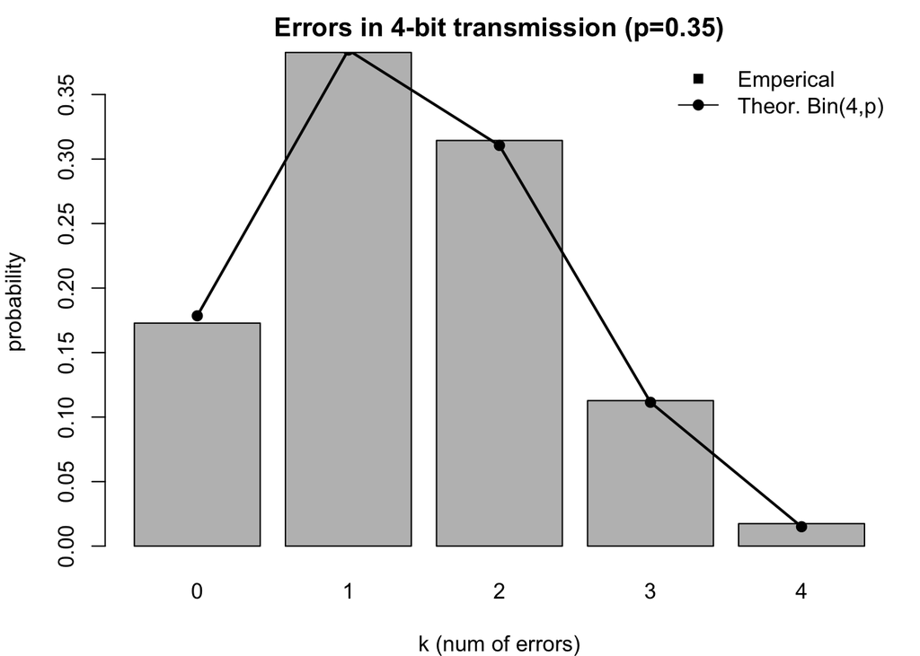

```r
M  <- 20000
k <- rbinom(M, size = 4, prob = p)

tab <- table(factor(k, levels=0:4))
freq <- as.numeric(tab) / sum(tab)

kvals <- 0:4
probs <- dbinom(kvals, size = 4, prob = p)

op <- par(mar=c(4,4,2,1))
bp <- barplot(freq,
              names.arg = kvals,
              xlab = "k (num of errors)",
              ylab = "probability",
              main = sprintf("Errors in 4-bit transmission (p=%.2f)", p))

points(bp, probs, pch = 19) # black - theoretical
lines(bp, probs, lwd = 2)
legend("topright", c("Emperical", "Theor. Bin(4,p)"),
       pch = c(15,19), lty = c(0,1), bty = "n")
```

```r
par(op)
```

And that’s Binomial distribution $k \sim Bin(4,p)$!

### Little summary

We learned how reliable the Hamming [7,4] code is under bit-flip noise p=id/100: by simulation we get $\hat p$, the fraction of messages that decode correctly, which converges to the true success probability $p^*$. We quantify uncertainty with a 95% confidence interval $\hat p \pm 1.96\sqrt{\hat p(1-\hat p)/N}$, so more trials make the estimate tighter. To guarantee a margin of at most 0.03, about $N≥1068$ runs are needed. And the number of errors when sending an uncoded 4-bit message follows a Binomial(4,p) distribution. That’s it.

### Task 2.

In this task, we discuss a real-life process that is well modelled by a Poisson distribution. As you remember, a Poisson random variable describes occurrences of rare events, i.e., counts the number of successes in a large number of independent random experiments. One of the typical examples is the **radioactive decay** process.

Consider a sample of radioactive element of mass $m$, which has a big *half-life period* $T$; it is vitally important to know the probability that during a one second period, the number of nuclei decays will not exceed some critical level $k$. This probability can easily be estimated using the fact that, given the *activity* ${\lambda}$ of the element (i.e., the probability that exactly one nucleus decays in one second) and the number $N$ of atoms in the sample, the random number of decays within a second is well modelled by Poisson distribution with parameter $\mu:=N\lambda$. Next, for the sample of mass $m$, the number of atoms is $N = \frac{m}{M} N_A$, where $N_A = 6 \times 10^{23}$ is the Avogadro constant, and $M$ is the molar (atomic) mass of the element. The activity of the element, $\lambda$, is $\log(2)/T$, where $T$ is measured in seconds.

Assume that a medical laboratory receives $n$ samples of radioactive element ${{}^{137}}\mathtt{Cs}$ (used in radiotherapy) with half-life period $T = 30.1$ years and mass $m = \mathtt{team\, id \,number} \times 10^{-6}$ g each. Denote by $X_1,X_2,\dots,X_n$ the **i.i.d. r.v.**’s counting the number of decays in sample $i$ in one second.

```r
T <- 30.1
m <- 35 * 10^(-6)
n <- 5
M <- 136.907089 # gram / mol this is the mass of c137
Na <- 6 * 10^23
n_list <- c(5, 10, 50)
# we need consistent units so our T must be converted from years to seconds we will calculate everything in seconds

T <- 30.1 * 365 * 24 * 60 * 60

T # = 949233600
```

```
## [1] 949233600
```

```r
# $\lambda$, is log(2)/T
# we found T so we can now calculate lambda (we need it to find mean)

lambda_for_all <- log(2) / T
lambda_for_all # = 7.302177e-10
```

```
## [1] 7.302177e-10
```

```r
# Now we can find N (number of atoms) = m/M NA

N <- m/M * Na
N # = 1.533887e+17
```

```
## [1] 1.533887e+17
```

```r
mu <- N * lambda_for_all
mu # = 112007142
```

```
## [1] 112007142
```

```r
# we have poisson distribution so it is easy for us to find sigma (= lambda) but we also should not forget that we search it per element and we have n of elements (=lambda/times). and sd would be sqrt of that value. BUT first I still calculated for all x-s
var_for_all <- mu
#sd_for_all <- sqrt(var_for_all) # in other words it is for whole distribution but since they are independent than later on we can just devide it by n (sum of independent poisson rv = poisson rv with new parameter)
#sigma_for_all # = 1.460435e-10
#sd_for_all # = 1.208485e-05
K <- 1e3 # times that our experiment is going to be repeated 1000



sample_means <- colMeans(matrix(rpois(n*K, lambda = mu), nrow=n)) # functrion that calculates the mean value of each column in a matrix of df VERY QUICK
# rpois generates randm nums from poisson distribution first param - num of rvs second- mean and variance
```

#### Next, calculate the parameters of the standard normal approximation

```r
mu <- mu
sigma <- sqrt(var_for_all/n)
```

#### We can now plot ecdf and cdf

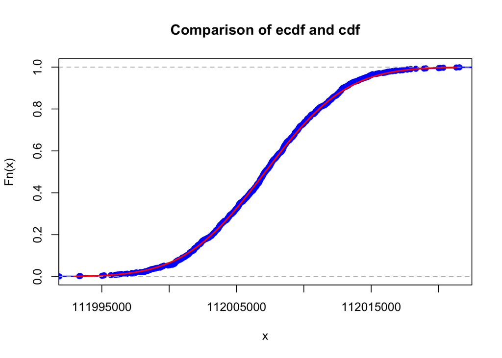

```r
xlims <- c(mu-3*sigma,mu+3*sigma)
Fs <- ecdf(sample_means)
plot(Fs,
     xlim = xlims,
     ylim = c(0,1),
     col = "blue",
     lwd = 2,
     main = "Comparison of ecdf and cdf")
curve(pnorm(x, mean = mu, sd = sigma), col = "red", lwd = 2, add = TRUE)
```

**Next, proceed with all the remaining steps. To sum up:**

```r
max_diffs <- numeric(length(n_list))
n_list <- c(5, 10, 50)
for (i in 1:length(n_list)) {
  n <- n_list[i]

  sample_means <- colMeans(matrix(rpois(n * K, lambda = mu), nrow = n))
  #Fs <- ecdf(sample_means)
  x_points <- seq(xlims[1], xlims[2], length.out = 1000)

  x_grid <- seq(min(sample_means), max(sample_means), length.out = 1000)
  ecdf_vals <- Fs(x_grid)
  cdf_vals  <- pnorm(x_grid, mean = mu, sd = sigma)

  max_diffs[i] <- max(abs(ecdf_vals - cdf_vals))
}

print("Maximal Differences")
```

```
## [1] "Maximal Differences"
```

```r
names(max_diffs) <- paste("n=", n_list)
print(max_diffs)
```

```
##       n= 5      n= 10      n= 50
## 0.01684936 0.01679575 0.01391462
```

```r
print("As n gets bigger we can sees that diff between cdf and ecdf gets smaller and smaller. which numerically confirms clt")
```

[output not shown]

```r
bound <- 8*10^8
# Markov's Inequality
# P(S n>= 8*10^8) <= E(Sn) / 8*10^8
# E(Sn) / 8*10^8 <= 1-0.95 = 0.05
# n * mu / 8*10^8 <= 0.05
# n <= (0.05 * 8*10^8) / mu
#print(bound)
#print(mu)
n_markov <- ((0.05 * bound) / mu)
cat("n <=", n_markov)
```

```
## n <= 0.3571201
```

```r
# CLT
# We want P(Sn >=  8*10^8) <= 0.05
#
# at first we can standardize it cause it has aproximately normal distribution (Sn - n*mu) / sqrt(n*mu) >= ( 8*10^8 - n*mu) / sqrt(n*mu)
# The 95th percentile for a standard Normal is z = 1.645
# So, we need: (8*10^8 - n*mu) / sqrt(n*mu) >= 1.645
# 8*10^8 - sqrt(n)^2*mu >= 1.645 * sqrt(n) * sqrt(mu)
# mu*sqrt(n)^2 + (1.645*sqrt(mu))*sqrt(n) -  8*10^8 <= 0

x <- (-( 1.645 * sqrt(mu)) + sqrt(( 1.645 * sqrt(mu))^2 - 4 * mu * (-bound))) / (2 * mu)
n_clt <- x^2

cat("CLT: n <=", x^2)
```

```
## CLT: n <= 7.141986
```

```r
#Chernoff
bound <- 8e8
mu_per_sample <- mu
desirable_prob <- 0.95

chernoff_log_root <- function(n) {
  lambda <- n * mu_per_sample # calculating parameter of  sum of poisson rv
  log_prob <- -lambda + bound * (1 + log(lambda / bound))
  return(log_prob - log(1 - desirable_prob))
}

library(stats)
result <- uniroot(chernoff_log_root, lower = 1, upper = 8e8/mu)
n_chernoff <- result$root

cat("Chernoff bound n_max =", n_chernoff, "\n")
```

```
## Chernoff bound n_max = 7.141791
```

```r
K_large <- 10000

set.seed(35)
sample_sums <- rpois(K_large, lambda = n_clt * mu)

successes <- sum(sample_sums < 8e8)
empirical_prob <- successes / K_large

cat(" n =", n_clt, "with K =", K_large)
```

```
##  n = 7.141986 with K = 10000
```

```r
cat("  empirical probability of sum < 8*10^8 is:", empirical_prob, "\n")
```

```
##   empirical probability of sum < 8*10^8 is: 0.9452
```

```r
print("The simulated probability is close to our target of 0.95, which confirms that our calculation for n using the CLT was correct")
```

```
## [1] "The simulated probability is close to our target of 0.95, which confirms that our calculation for n using the CLT was correct"
```

Analyzing the plot: This plot is really beautiful, it clearly shows us that emperical cdf of our experimental data which is almost the same as theoretical cdf of Normal distribution with parameters that you can see above. First of all it is like visual confirmation that CLT works. Even though we had Poisson distribution for each particular x the distribution of the sample means is really close to normal distribution!!

What we have done in task 2:

Task 3.

In this task, we use the Central Limit Theorem approximation for continuous random variables.

One of the devices to measure radioactivity level at a given location is the Geiger counter. When the radioactive level is almost constant, the time between two consecutive clicks of the Geiger counter is an exponentially distributed random variable with parameter $\nu_1 = \mathtt{team\,id\,number} + 10$. Denote by $X_k$ the random time between the $(k-1)^{\mathrm{st}}$ and $k^{\mathrm{th}}$ click of the counter.

Show that the distribution of the sample means of $X_1, X_2,\dots,X_n$ gets very close to a normal one (which one?) as $n$ becomes large. To this end,

simulate the realizations $x_1,x_2,\dots,x_n$ of the $\textbf{r.v.}$ $X_i$ and calculate the sample mean $s=\overline{\mathbf{x}}$;

repeat this $K$ times to get the sample $\mathbf{s}=(s_1,\dots,s_K)$ of means and then the $\textit{empirical cumulative distribution}$ function $F_{\mathbf{s}}$ of $\mathbf{s}$;

identify $\mu$ and $\sigma^2$ such that the $\textbf{c.d.f.}$ of $\mathscr{N}(\mu,\sigma^2)$ is close to the $\textbf{e.c.d.f.}$ $F_{\mathbf{s}}$ of and plot both $\textbf{c.d.f.}$’s on one graph to visualize their proximity;

calculate the maximal difference between the two $\textbf{c.d.f.}$’s;

consider cases $n = 5$, $n = 10$, $n=50$ and comment on the results.

The place can be considered safe when the number of clicks in one minute does not exceed $100$. It is known that the parameter $\nu$ of the resulting exponential distribution is proportional to the number $N$ of the radioactive samples, i.e., $\nu = \nu_1*N$, where $\nu_1$ is the parameter for one sample. Determine the maximal number of radioactive samples that can be stored in that place so that, with probability $0.95$, the place is identified as safe. To do this,

express the event of interest in terms of the $\textbf{r.v.}$ $S:= X_1 + \cdots + X_{100}$;

obtain the theoretical bounds on $N$ using the Markov inequality, Chernoff bound and Central Limit Theorem and compare the results;

with the predicted $N$ and thus $\nu$, simulate the realization $x_1,x_2,\dots,x_{100}$ of the $X_i$ and of the sum $S = X_1 + \cdots + X_{100}$;

repeat this $K$ times to get the sample $\mathbf{s}=(s_1,\dots,s_K)$ of total times until the $100^{\mathrm{th}}$ click;

estimate the probability that the location is identified as safe and compare to the desired level $0.95$

First, generate samples an sample means:

```r
nu1 <- 45
K <- 1e3
#n <- 5
n_list <- c(5, 10, 50)
for (n in n_list){
  sample_means <- colMeans(matrix(rexp(n*K, rate = nu1), nrow=n))
  cat("for n =", n, " mean of sample means = ", mean(sample_means))

}
```

```
## for n = 5  mean of sample means =  0.02242665for n = 10  mean of sample means =  0.02240984for n = 50  mean of sample means =  0.02212946
```

Next, calculate the parameters of the standard normal approximation

```r
exp_mean <- 1/nu1
exp_var <- 1 / nu1^2
exp_sd <- exp_mean

mu <- exp_mean
sigma <- exp_sd / sqrt(n)
#print(n)
```

We can now plot ecdf and cdf

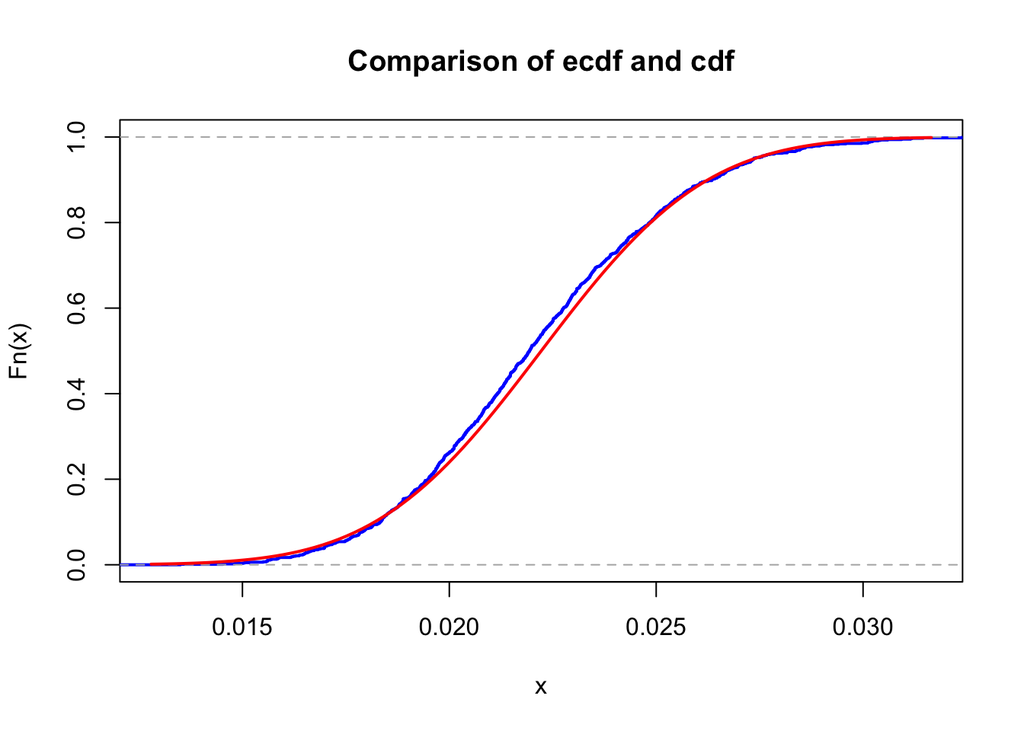

```r
xlims <- c(mu-3*sigma,mu+3*sigma)
Fs <- ecdf(sample_means)
plot(Fs,
     xlim = xlims,
     col = "blue",
     lwd = 2,
     main = "Comparison of ecdf and cdf")
curve(pnorm(x, mean = mu, sd = sigma), col = "red", lwd = 2, add = TRUE)
```